# 2019-09-21__explore-persona-model

# Model Performance

- Num. Personas $\in \{25, 50, 100\}$
- Num. Topics $\in \{25, 50, 100\}$

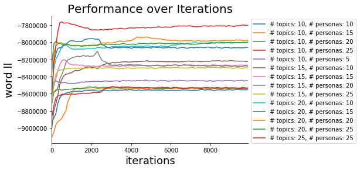

# Exploratory Data Analysis

In the paper, Bamman et. al. show two main exploratory analyses:

- Top words by topic
- Top topics by persona (across agent, patient and modifier categories)

We replicate these results in the following section.

## View topics

| TELL kill take arrest see charge send find ask shoot | TELL ask give accuse expect support call criticize see force | DOCTOR defendant researcher client hostage authority southern militant chancellor german | COMPANY governor city judge department guerrilla bishop baby girl trustee | MOTHER wife daughter brother friend girl detainee sister neighbor father | CHILD member victim voter inmate other many recipient respondent adult | MAN officer soldier prisoner gunman fighter young american passenger suspect | FATHER administration refugee contra driver engineer albanian serb suspect ethnic | SAY add think believe note expect acknowledge know call see | LAWYER judge prosecutor general counsel independent witness contractor attorney special |
| --- | --- | --- | --- | --- | --- | --- | --- | --- | --- |
| WOMAN employee many resident customer citizen northern young user trader | ALLOW give leave require force pay expect use join make | MAKE have do want tell call take win go seek | LEADER candidate republican democratic senator pilot opponent democrat lawmaker conservative | STUDENT parent worker teacher kid many farmer participant astronaut broker | PRESIDENT director executive spokesman expert chairman scientist analyst professor chief | OFFICIAL aide senior american mayor adviser rebel diplomat commander military | HAVE take agree do make try begin be need find | HUSBAND minister juror negotiator marine prime guard priest dealer insurgent | COUNTRY government state party nation court employer investor maker producer |
| PATIENT son boy immigrant relative nurse settler protester miner illegal | MAN one person guy old friend sure father young veteran | SAY have go tell do know get want see take | INVESTIGATOR inspector player owner manager partner plaintiff pope carrier detective | THIS able member former willing supporter new one likely ready |  |  |  |  |  |

# View top personas

|  | Persona | Frequency | Topic Words | Sample Characters |
| --- | --- | --- | --- | --- |
| 0 | 23 | 0.091094 | [$\text{SAY}_{agent}$, $\text{PRESIDENT}_{mod}$, $\text{HAVE}_{agent}$] | [Dr. Setzer, Dr. Manasse, Mr. Kolstad, Mr. Moore, Dr. Pak] |
| 1 | 14 | 0.088887 | [$\text{SAY}_{agent}$, $\text{OFFICIAL}_{mod}$, $\text{MAKE}_{agent}$] | [Mr. Shultz, a diplomat, the official, the rebels, Cardinal Ballestrero] |
| 2 | 22 | 0.071688 | [$\text{LEADER}_{mod}$, $\text{MAKE}_{agent}$, $\text{SAY}_{agent}$] | [Mr. Gorbachev, leader, the Democrats, several candidates, Mr. Reagan] |
| 3 | 12 | 0.061751 | [$\text{MAN}_{mod}$, $\text{SAY}_{agent}$, $\text{TELL}_{mod}$] | [Mr. Harvey, Mr. Ji, gay and bisexual men, Mr. King, The second suspect , identified as Flavio P... |
| 4 | 8 | 0.052223 | [$\text{HAVE}_{agent}$, $\text{COUNTRY}_{mod}$, $\text{ALLOW}_{mod}$] | [Pakistan, The Government, Israel, the Labor Party, Japan] |
| 5 | 19 | 0.049930 | [$\text{SAY}_{agent}$, $\text{MOTHER}_{mod}$, $\text{TELL}_{mod}$] | [Mr. Ashbrook, Mr. Smith, Michael, the Jews, his wife] |
| 6 | 6 | 0.042686 | [$\text{LAWYER}_{mod}$, $\text{SAY}_{agent}$, $\text{HAVE}_{agent}$] | [one associate, The prosecutors, the judge, Mr. Phelan, Mr. Dall] |
| 7 | 24 | 0.039443 | [$\text{STUDENT}_{mod}$, $\text{SAY}_{agent}$, $\text{HAVE}_{agent}$] | [the students, the workers, the President-elect, Mr. Possner, The worker] |
| 8 | 11 | 0.037645 | [$\text{SAY}_{agent}$, $\text{SAY}_{agent}$, $\text{MAN}_{mod}$] | [Justice Blackmun, Mr. Abdullah, Mr. Shata, Mr. Fortier, Ferreira] |
| 9 | 0 | 0.036269 | [$\text{SAY}_{agent}$, $\text{MAN}_{mod}$, $\text{MAKE}_{agent}$] | [Mr. Frankel, Hess, Mr. Lai, I, Mr. Jackson] |

# Next steps:

- Problems with entity extraction:
  - Bamman et. al's model doesn't do a good job of capturing named entities without referents
  - Their model extracts non named-entity coreferents
- Problems with vocabulary
  - Their criterion is perhaps ill-suited for a news domain, where many witnesses are not doing anything.
  - Their criterion doesn't capture quotes or parenthetical asides.
- Latent document topics?
- What to do with this work?